# F1 Prediction

G13 - Alberico Emanuele, Ludovico Lentini, Camilla Lombardi, Matteo Saba

7/16/2022

```r
library(readr)
library(naivebayes)
library(dplyr)
```

```r
library(ggplot2)
library(ggplot2)     # to plot
library(gridExtra)   # to put more
library(grid)        # plot together

##setwd("C:/Users/aeman/OneDrive/Desktop/F1 2")
setwd("~/Desktop/FORMULA1")
DB_FINAL <- read_csv("DB_FINAL.csv")
dati<-DB_FINAL
```

### Data manipulation

The first thing that we observe is that many teams changed their names over the period considered. So, in this part we replace the old names with the current ones.

```r
dati$Team[dati$Team=="Sauber"]<- "Alfa Romeo"
dati$Team[dati$Team=="Toro Rosso"]<- "AlphaTauri"
dati$Team[dati$Team=="Renault" | dati$Team=="Lotus F1"]<- "Alpine F1 Team"
dati$Team[dati$Team=="Force India" | dati$Team=="Racing Point"]<- "Aston Martin"
dati$Team[dati$Team=="Manor Marussia"]<- "Marussia"
```

Going on, we believe that there could be some custom variables which could be useful in the prediction. So we decided to implement the ratio of DNF (Not finished races) and the ratio of wins per driver and per team. Since our analysis is limited tot he year 2014-2021, we are just considering the drivers and the teams that raced in this timeframe.

To create the DNF variable per driver we considered the number of races that the driver didn’t finish over the races to which he partecipated. Of course, since we are trying to predict the podiums for each race, we are updating this variable in each race. Another assumption on which we based our custom variable is that we are just considering the DNF of the races between 2014 and 2021 without considering the previous races. This decision was made because in 2014 a new engine was introduced and we didn’t consider correct to add also precious DNF.

```r
#Creation of the binary variable DNF(=1 if a driver had a DNF and 0 otherwise)
dati$DNF<- list(0)
DNF<-c(3,4,20,29,31,41,68,73,81,97,82,104,107,130,137)
for (i in DNF) {
  dati$DNF[dati$statusId==i]<- 1
}
dati$DNF<-as.numeric(dati$DNF)

#Creation of the variable TASSO_DNF which is the percentage of DNF of each driver.
#IN CIASCUNA GARA
cumulata_gare_2014_2021<- data.frame(table(dati$Driver))
cumulata_gare_2014_2021$Freq<-0

cumulata_DNF_2014_2021<- data.frame(table(dati$Driver))
cumulata_DNF_2014_2021$Freq<-0

tasso_DNF<-list()
for (i in 1:nrow(dati)) {
  perc<- (cumulata_DNF_2014_2021$Freq[cumulata_DNF_2014_2021$Var1==dati$Driver[i]]/cumulata_gare_2014_2021$Freq[cumulata_gare_2014_2021$Var1==dati$Driver[i]])*100
  tasso_DNF<-append(tasso_DNF,perc)
  cumulata_gare_2014_2021$Freq[cumulata_gare_2014_2021$Var1==dati$Driver[i]]<-cumulata_gare_2014_2021$Freq[cumulata_gare_2014_2021$Var1==dati$Driver[i]]+1
  if(dati$DNF[i]==1)
    cumulata_DNF_2014_2021$Freq[cumulata_DNF_2014_2021$Var1==dati$Driver[i]]<-cumulata_DNF_2014_2021$Freq[cumulata_DNF_2014_2021$Var1==dati$Driver[i]]+1
}

dati$tasso_DNF<-tasso_DNF
dati$tasso_DNF[dati$tasso_DNF=="NaN"]<-0
```

```r
#CARICO FILE DEL NUMERO DI GARE VINTE DA OGNI PILOTA FINO AL 2014
setwd("~/Desktop/FORMULA1")
cumulata_vittorie<- read_csv("Vittorie per pilota prima del 2014.csv")
t<-data.frame(table(dati$Driver))
for (i in cumulata_vittorie$Driver) {
  t$Freq[t$Var1==i]<- cumulata_vittorie$`count(vittorie_pilota)`[cumulata_vittorie$Driver==i]
}
t$Freq[t$Var1!= "Alonso" & t$Var1!= "Hamilton" & t$Var1!= "Räikkönen" & t$Var1!= "Vettel" & t$Var1!= "Ricciardo" & t$Var1!= "Bottas" & t$Var1!= "Pérez" & t$Var1!= "Kubica" & t$Var1!= "Massa" & t$Var1!= "Button" & t$Var1!= "Rosberg" & t$Var1!= "Maldonado"]<-0
cumulata_vittorie_2014<- t

#CARICO IL FILE DEL NUMERO DI GARE CORSE DA OGNI PILOTA FINO AL 2014
t<-data.frame(table(dati$Driver))
cumulata_gare_2014 <- read_csv("GP disputati per pilota prima del 2014.csv")
for (i in cumulata_gare_2014$Driver) {
  t$Freq[t$Var1==i]<- cumulata_gare_2014$`count(raceId)`[cumulata_gare_2014$Driver==i]
}
t$Freq[t$Var1!= "Alonso" & t$Var1!= "Hamilton" & t$Var1!= "Räikkönen" & t$Var1!= "Vettel" & t$Var1!= "Ricciardo" & t$Var1!= "Bottas" & t$Var1!= "Pérez" & t$Var1!= "Kubica" & t$Var1!= "Massa" & t$Var1!= "Button" & t$Var1!= "Rosberg" & t$Var1!= "Maldonado" & t$Var1!= "Sutil" & t$Var1!= "Hülkenberg" & t$Var1!= "Kobayashi" & t$Var1!= "Grosjean" & t$Var1!= "Gutiérrez" & t$Var1!= "Vergne" & t$Var1!= "Chilton" & t$Var1!= "Bianchi" & t$Var1!= "di Resta" ]<-0
cumulata_gare_2014<-t

#CREO LA VARIABILE TASSO_WIN CHE INDICA LA PERCENTUALE DI VITTORIA
#DI OGNI PILOTA IN CIASCUNA CORSA
tasso_win<-list()
for (i in 1:nrow(dati)) {
  perc<- (cumulata_vittorie_2014$Freq[cumulata_vittorie_2014$Var1==dati$Driver[i]]/cumulata_gare_2014$Freq[cumulata_gare_2014$Var1==dati$Driver[i]])*100
  tasso_win<-append(tasso_win,perc)
  cumulata_gare_2014$Freq[cumulata_gare_2014$Var1==dati$Driver[i]]<-cumulata_gare_2014$Freq[cumulata_gare_2014$Var1==dati$Driver[i]]+1
  if(dati$driver_wins[i]==1)
    cumulata_vittorie_2014$Freq[cumulata_vittorie_2014$Var1==dati$Driver[i]]<- cumulata_vittorie_2014$Freq[cumulata_vittorie_2014$Var1==dati$Driver[i]]+1
}

dati$tasso_win<-tasso_win
dati$tasso_win[dati$tasso_win=="NaN"]<-0
```

### Exploration Data Analysis

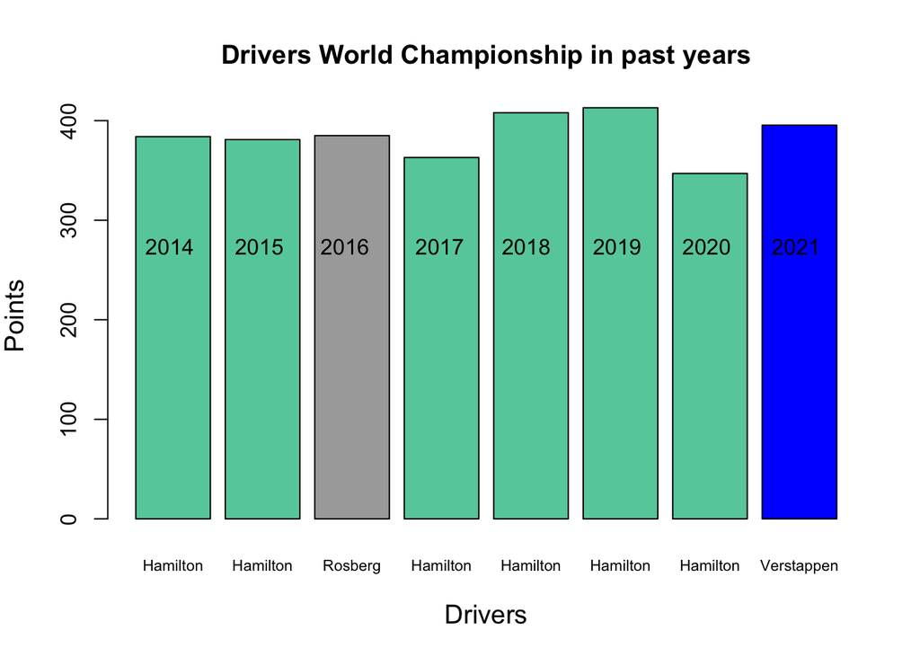

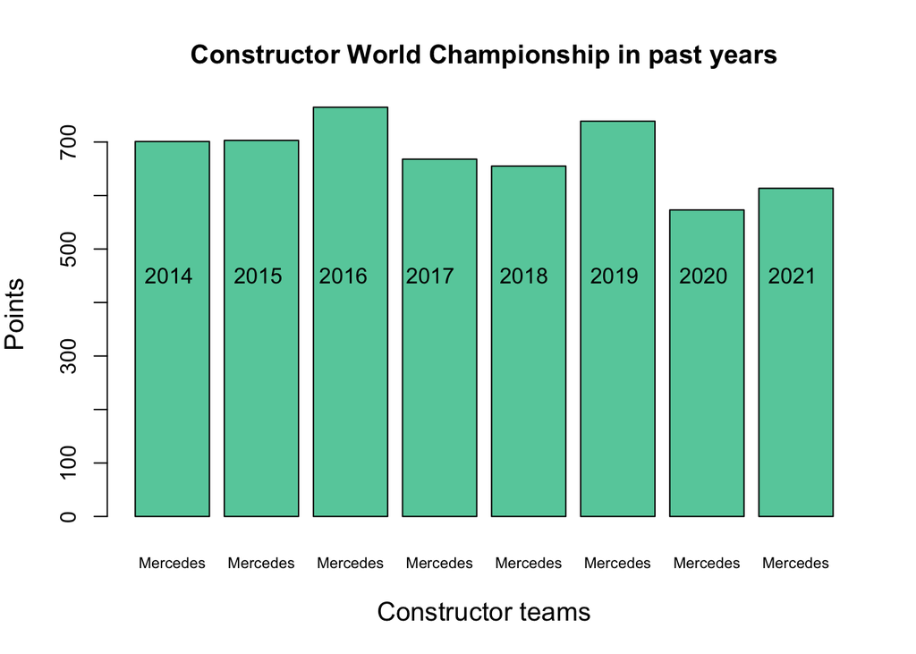

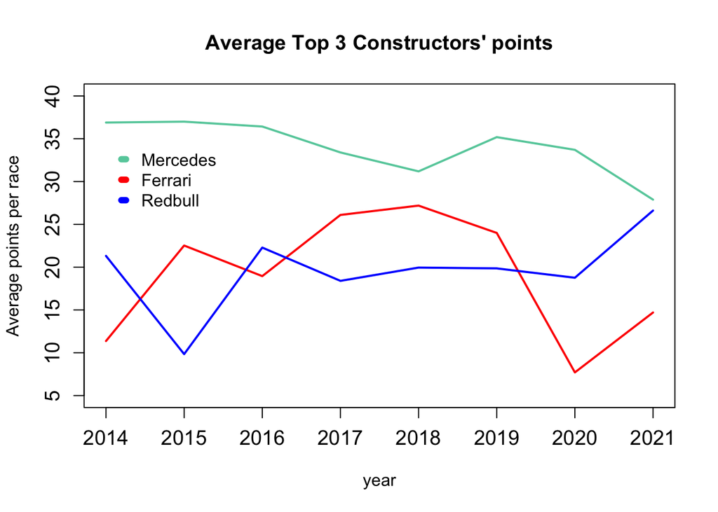

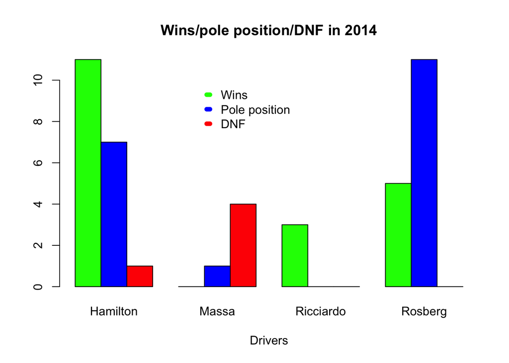

```r
#GRAFICI PILOTI PER VITTORIE POLE E DNF
table(DB2014$Driver[DB2014$positionText==1])
table(DB2014$Driver[DB2014$quali_position==1])
table(DB2014$Driver[DB2014$DNF==1])

w14=c(11,0,3,5)
q14=c(7,1,0,11)
v14=c(1,4,0,0)


barplot(rbind(w14,q14,v14),width=3 ,beside = T, names.arg = c("Hamilton","Massa","Ricciardo","Rosberg"), col = c("green","blue","red"), main="Wins/pole position/DNF in 2014",
        xlab="Drivers")
leg.txta =c("Wins","Pole position","DNF")
legend(17,10,leg.txta,lty=1, bty="n", col =c("green","blue","red"), lwd = 6 ,seg.len = 0.3)
```

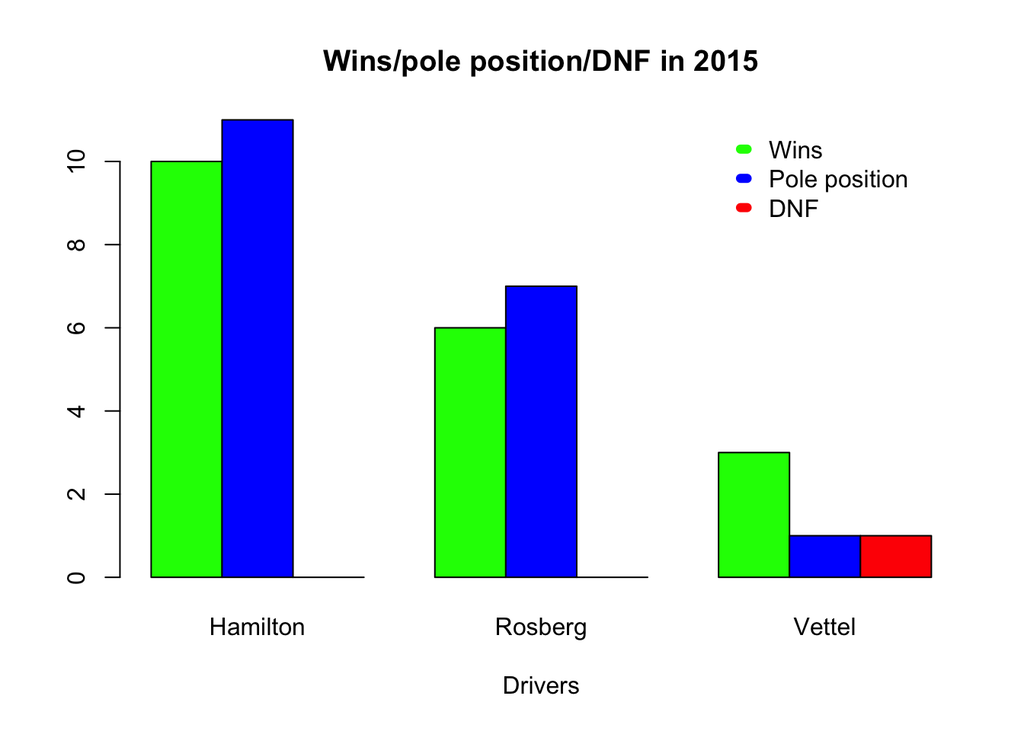

```r
#2015

table(DB2015$Driver[DB2015$positionText==1])
table(DB2015$Driver[DB2015$quali_position==1])
table(DB2015$Driver[DB2015$DNF==1])

w15=c(10,6,3)
q15=c(11,7,1)
v15=c(0,0,1)

barplot(rbind(w15,q15,v15),width=3 ,beside = T, names.arg = c("Hamilton","Rosberg","Vettel"), col = c("green","blue","red"), main="Wins/pole position/DNF in 2015",
        xlab="Drivers")
leg.txta =c("Wins","Pole position","DNF")
legend(27,11,leg.txta,lty=1, bty="n", col =c("green","blue","red"), lwd = 6 ,seg.len = 0.3)
```

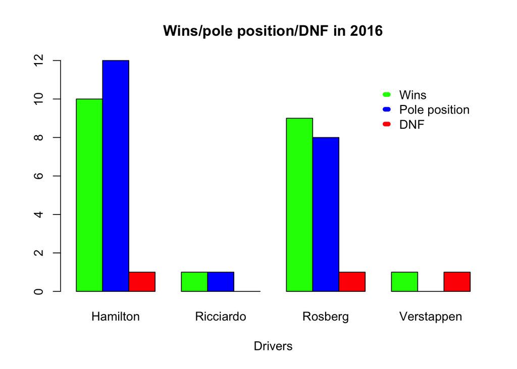

```r
#2016

table(DB2016$Driver[DB2016$positionText==1])
table(DB2016$Driver[DB2016$quali_position==1])
table(DB2016$Driver[DB2016$DNF==1])

w16=c(10,1,9,1)
q16=c(12,1,8,0)
v16=c(1,0,1,1)

barplot(rbind(w16,q16,v16),width=3 ,beside = T, names.arg = c("Hamilton","Ricciardo","Rosberg","Verstappen"), col = c("green","blue","red"), main="Wins/pole position/DNF in 2016",
        xlab="Drivers")
leg.txta =c("Wins","Pole position","DNF")
legend(37,11,leg.txta,lty=1, bty="n", col =c("green","blue","red"), lwd = 6 ,seg.len = 0.3)
```

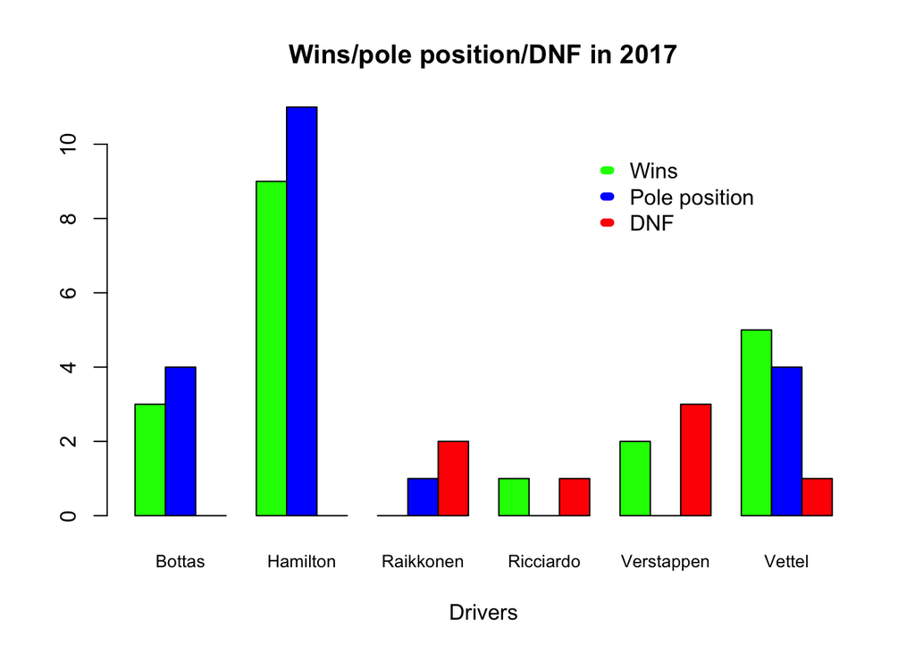

```r
#2017

table(DB2017$Driver[DB2017$positionText==1])
table(DB2017$Driver[DB2017$quali_position==1])
table(DB2017$Driver[DB2017$DNF==1])

w17=c(3,9,0,1,2,5)
q17=c(4,11,1,0,0,4)
v17=c(0,0,2,1,3,1)

barplot(rbind(w17,q17,v17),width=6 ,beside = T, names.arg = c("Bottas","Hamilton","Raikkonen","Ricciardo","Verstappen","Vettel"), col = c("green","blue","red"), main="Wins/pole position/DNF in 2017",
        xlab="Drivers",cex.names = 0.8)
leg.txta =c("Wins","Pole position","DNF")
legend(95,10,leg.txta,lty=1, bty="n", col =c("green","blue","red"), lwd = 6 ,seg.len = 0.3)
```

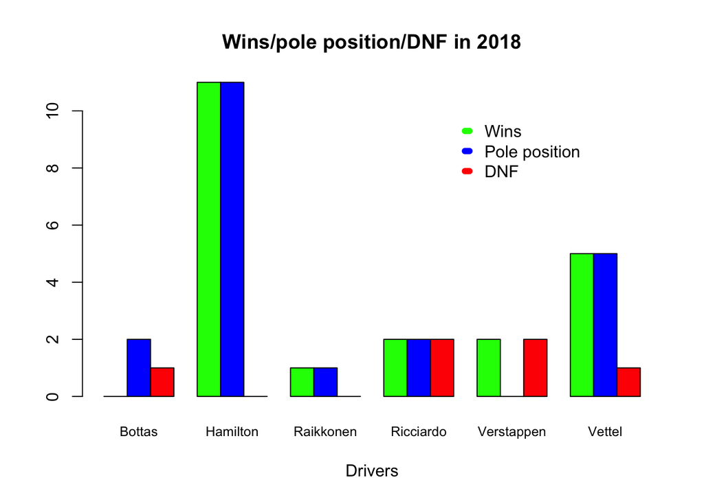

```r
#2018

table(DB2018$Driver[DB2018$positionText==1])
table(DB2018$Driver[DB2018$quali_position==1])
table(DB2018$Driver[DB2018$DNF==1])

w18=c(0,11,1,2,2,5)
q18=c(2,11,1,2,0,5)
v18=c(1,0,0,2,2,1)

barplot(rbind(w18,q18,v18),width=6 ,beside = T, names.arg = c("Bottas","Hamilton","Raikkonen","Ricciardo","Verstappen","Vettel"), col = c("green","blue","red"), main="Wins/pole position/DNF in 2018",
        xlab="Drivers",cex.names = 0.8)
leg.txta =c("Wins","Pole position","DNF")
legend(95,10,leg.txta,lty=1, bty="n", col =c("green","blue","red"), lwd = 6 ,seg.len = 0.3,)
```

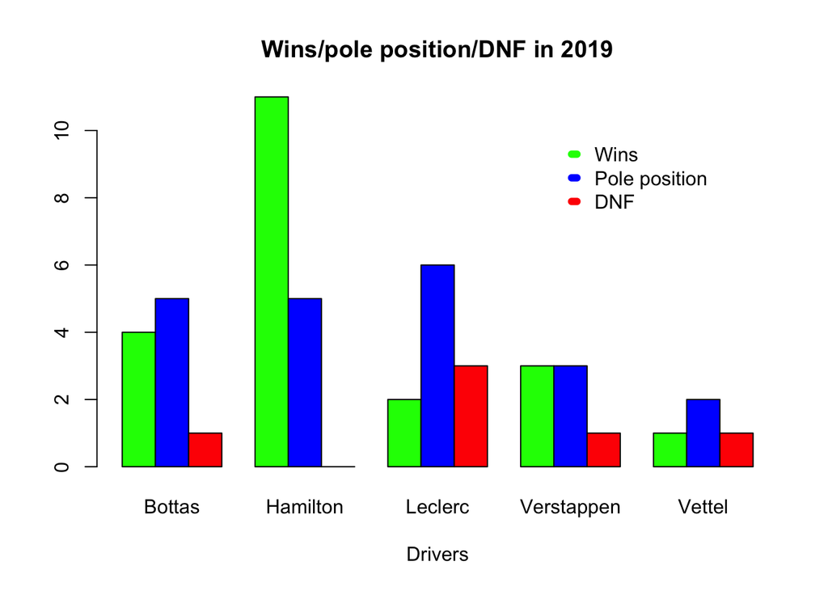

```r
#2019

table(DB2019$Driver[DB2019$positionText==1])
table(DB2019$Driver[DB2019$quali_position==1])
table(DB2019$Driver[DB2019$DNF==1])

w19=c(4,11,2,3,1)
q19=c(5,5,6,3,2)
v19=c(1,0,3,1,1)

barplot(rbind(w19,q19,v19),width=5 ,beside = T, names.arg = c("Bottas","Hamilton","Leclerc","Verstappen","Vettel"), col = c("green","blue","red"), main="Wins/pole position/DNF in 2019",
        xlab="Drivers")
leg.txta =c("Wins","Pole position","DNF")
legend(70,10,leg.txta,lty=1, bty="n", col =c("green","blue","red"), lwd = 6 ,seg.len = 0.3)
```

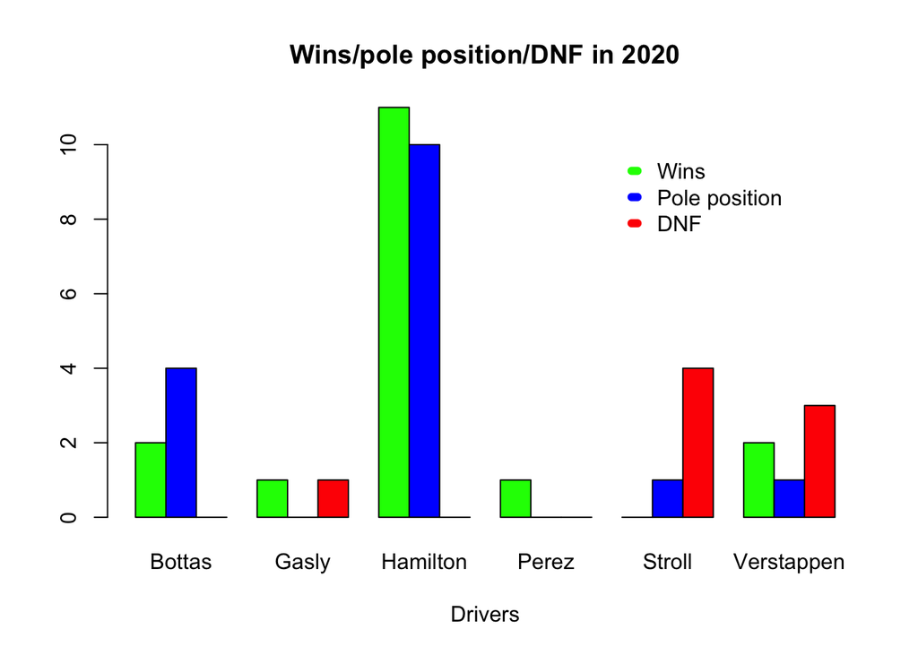

```r
#2020

table(DB2020$Driver[DB2020$positionText==1])
table(DB2020$Driver[DB2020$quali_position==1])
table(DB2020$Driver[DB2020$DNF==1])

w20=c(2,1,11,1,0,2)
q20=c(4,0,10,0,1,1)
v20=c(0,1,0,0,4,3)

barplot(rbind(w20,q20,v20),width=6 ,beside = T, names.arg = c("Bottas","Gasly","Hamilton","Perez","Stroll","Verstappen"), col = c("green","blue","red"), main="Wins/pole position/DNF in 2020",
        xlab="Drivers")
leg.txta =c("Wins","Pole position","DNF")
legend(100,10,leg.txta,lty=1, bty="n", col =c("green","blue","red"), lwd = 6 ,seg.len = 0.3)
```

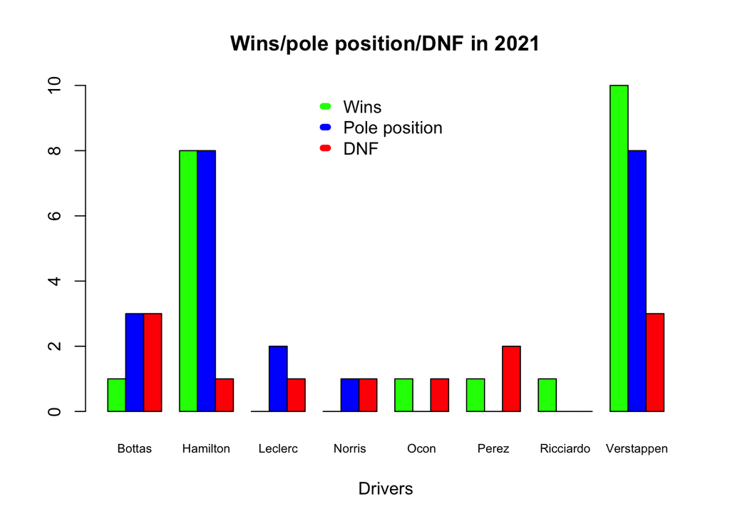

```r
#2021

table(DB2021$Driver[DB2021$positionText==1])
table(DB2021$Driver[DB2021$quali_position==1])
table(DB2021$Driver[DB2021$DNF==1])

w21=c(1,8,0,0,1,1,1,10)
q21=c(3,8,2,1,0,0,0,8)
v21=c(3,1,1,1,1,2,0,3)

barplot(rbind(w21,q21,v21),width=8 ,beside = T, names.arg = c("Bottas","Hamilton","Leclerc","Norris","Ocon","Perez","Ricciardo","Verstappen"), col = c("green","blue","red"), main="Wins/pole position/DNF in 2021",
        xlab="Drivers",cex.names = 0.7)
leg.txta =c("Wins","Pole position","DNF")
legend(97,10,leg.txta,lty=1, bty="n", col =c("green","blue","red"), lwd = 6 ,seg.len = 0.3)
```

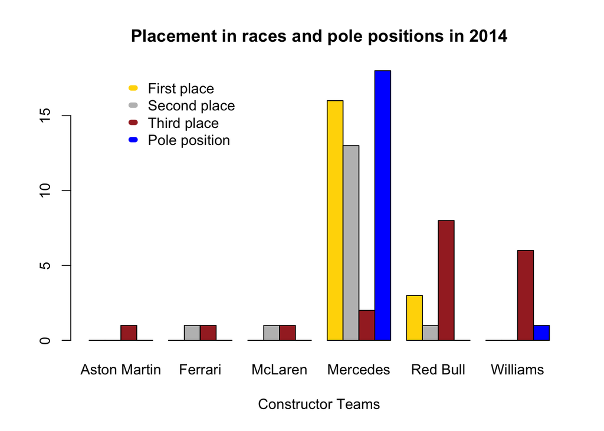

```r
#GRAFICI TEAMS PER PODI/POLE E STATUS

#2014

table(DB2014$Team[DB2014$positionText==1])
table(DB2014$Team[DB2014$positionText==2])
table(DB2014$Team[DB2014$positionText==3])

table(DB2014$Team[DB2014$quali_position==1])

f14=c(0,0,0,16,3,0)
s14=c(0,1,1,13,1,0)
t14=c(1,1,1,2,8,6)
p14=c(0,0,0,18,0,1)

barplot(rbind(f14,s14,t14,p14),width=6 ,beside = T, names.arg = c("Aston Martin","Ferrari","McLaren","Mercedes","Red Bull","Williams"), col = c("Gold","Grey","Brown","Blue"), main="Placement in races and pole positions in 2014",
        xlab="Constructor Teams")
leg.txta =c("First place","Second place","Third place","Pole position")
legend(17,18,leg.txta,lty=1, bty="n", col =c("Gold","Grey","Brown","Blue"), lwd = 6 ,seg.len = 0.3)
```

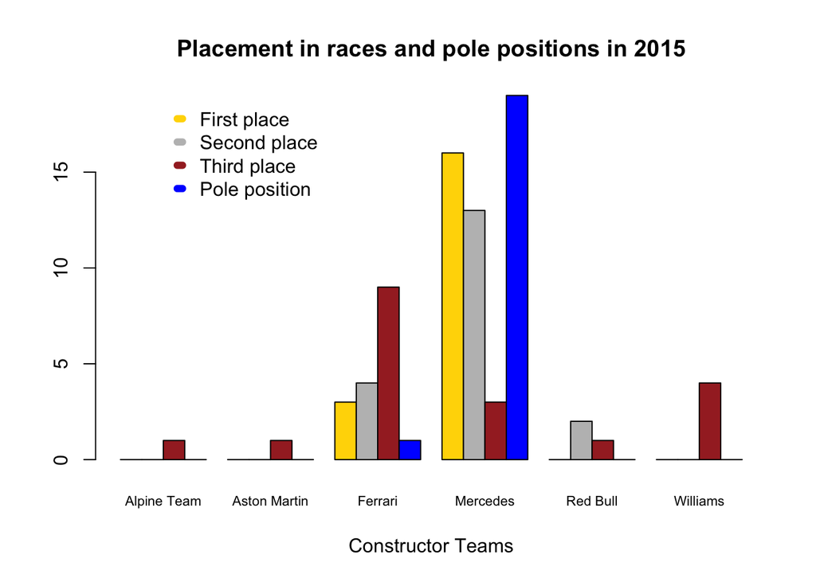

```r
#2015

table(DB2015$Team[DB2015$positionText==1])
table(DB2015$Team[DB2015$positionText==2])
table(DB2015$Team[DB2015$positionText==3])

table(DB2015$Team[DB2015$quali_position==1])

f15=c(0,0,3,16,0,0)
s15=c(0,0,4,13,2,0)
t15=c(1,1,9,3,1,4)
p15=c(0,0,1,19,0,0)


barplot(rbind(f15,s15,t15,p15),width=6 ,beside = T, names.arg = c("Alpine Team","Aston Martin","Ferrari","Mercedes","Red Bull","Williams"), col = c("Gold","Grey","Brown","Blue"), main="Placement in races and pole positions in 2015",
        xlab="Constructor Teams",cex.names = 0.7)
leg.txta =c("First place","Second place","Third place","Pole position")
legend(17,19,leg.txta,lty=1, bty="n", col =c("Gold","Grey","Brown","Blue"), lwd = 6 ,seg.len = 0.3)
```

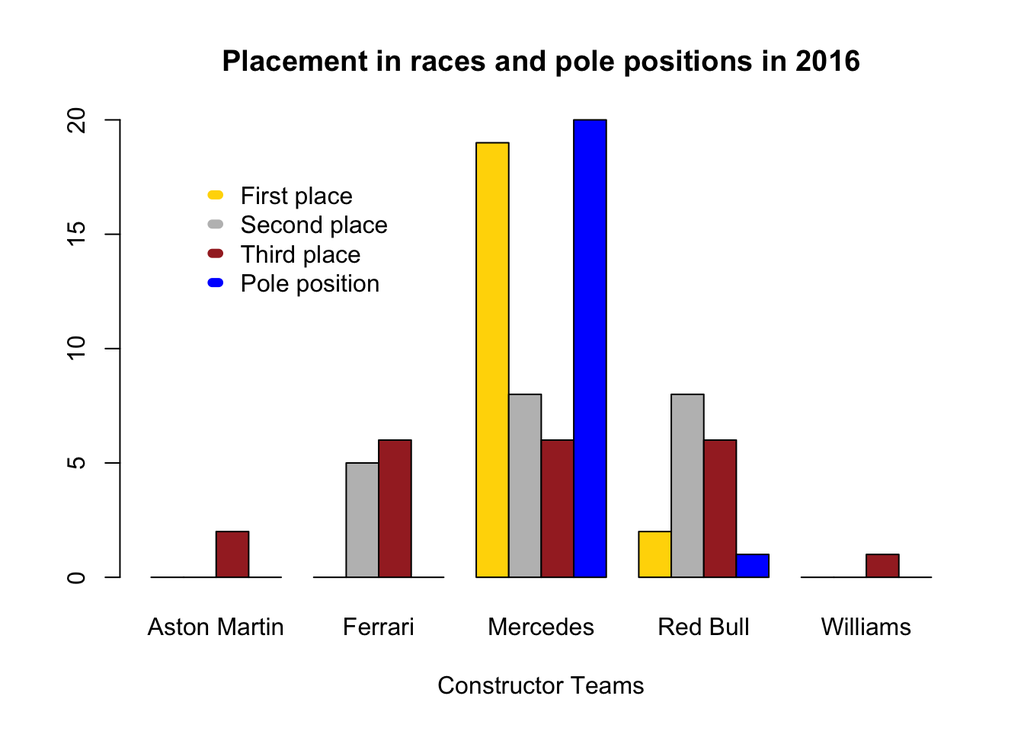

```r
#2016

table(DB2016$Team[DB2016$positionText==1])
table(DB2016$Team[DB2016$positionText==2])
table(DB2016$Team[DB2016$positionText==3])

table(DB2016$Team[DB2016$quali_position==1])

f16=c(0,0,19,2,0)
s16=c(0,5,8,8,0)
t16=c(2,6,6,6,1)
p16=c(0,0,20,1,0)

barplot(rbind(f16,s16,t16,p16),width=5 ,beside = T, names.arg = c("Aston Martin","Ferrari","Mercedes","Red Bull","Williams"), col = c("Gold","Grey","Brown","Blue"), main="Placement in races and pole positions in 2016",
        xlab="Constructor Teams")
leg.txta =c("First place","Second place","Third place","Pole position")
legend(11,18,leg.txta,lty=1, bty="n", col =c("Gold","Grey","Brown","Blue"), lwd = 6 ,seg.len = 0.3)
```

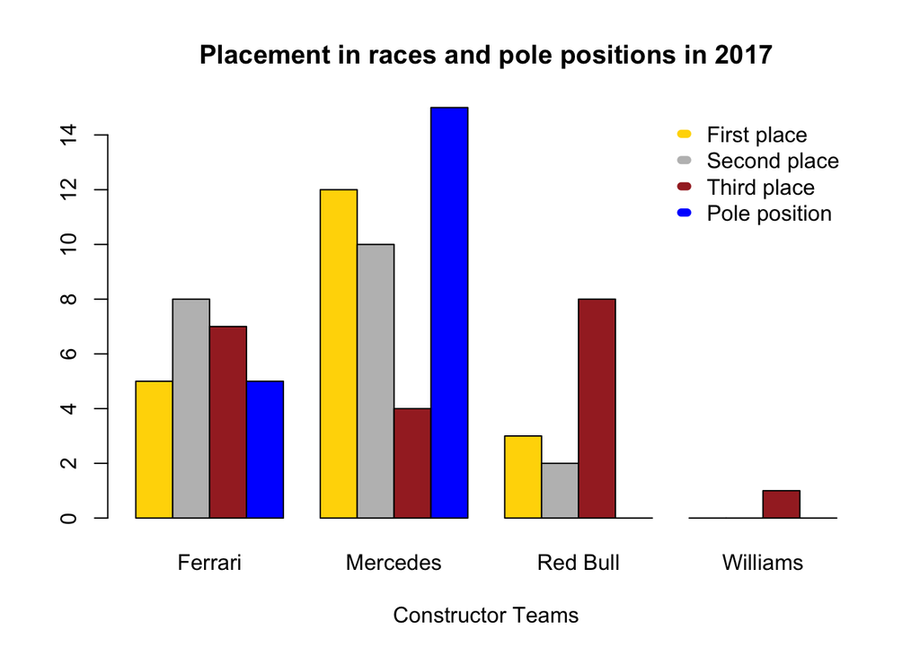

```r
#2017

table(DB2017$Team[DB2017$positionText==1])
table(DB2017$Team[DB2017$positionText==2])
table(DB2017$Team[DB2017$positionText==3])

table(DB2017$Team[DB2017$quali_position==1])

f17=c(5,12,3,0)
s17=c(8,10,2,0)
t17=c(7,4,8,1)
p17=c(5,15,0,0)

barplot(rbind(f17,s17,t17,p17),width=4 ,beside = T, names.arg = c("Ferrari","Mercedes","Red Bull","Williams"), col = c("Gold","Grey","Brown","Blue"), main="Placement in races and pole positions in 2017",
        xlab="Constructor Teams")
leg.txta =c("First place","Second place","Third place","Pole position")
legend(61,15,leg.txta,lty=1, bty="n", col =c("Gold","Grey","Brown","Blue"), lwd = 6 ,seg.len = 0.3)
```

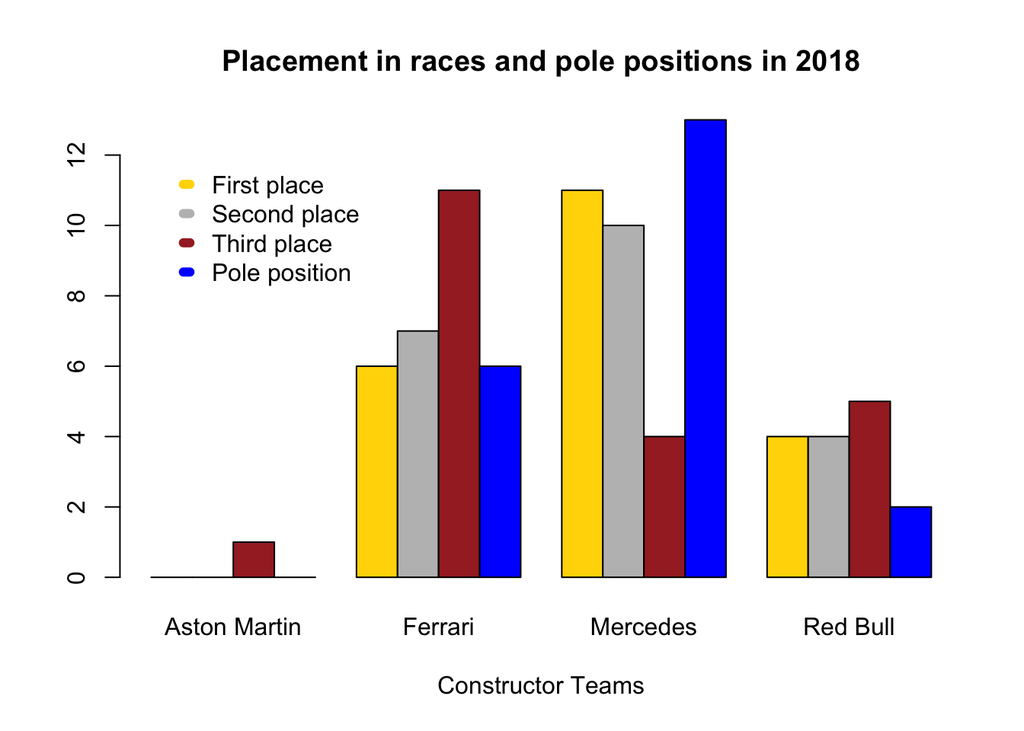

```r
#2018

table(DB2018$Team[DB2018$positionText==1])
table(DB2018$Team[DB2018$positionText==2])
table(DB2018$Team[DB2018$positionText==3])

table(DB2018$Team[DB2018$quali_position==1])

f18=c(0,6,11,4)
s18=c(0,7,10,4)
t18=c(1,11,4,5)
p18=c(0,6,13,2)


barplot(rbind(f18,s18,t18,p18),width=4 ,beside = T, names.arg = c("Aston Martin","Ferrari","Mercedes","Red Bull"), col = c("Gold","Grey","Brown","Blue"), main="Placement in races and pole positions in 2018",
        xlab="Constructor Teams")
leg.txta =c("First place","Second place","Third place","Pole position")
legend(5,12,leg.txta,lty=1, bty="n", col =c("Gold","Grey","Brown","Blue"), lwd = 6 ,seg.len = 0.3)
```

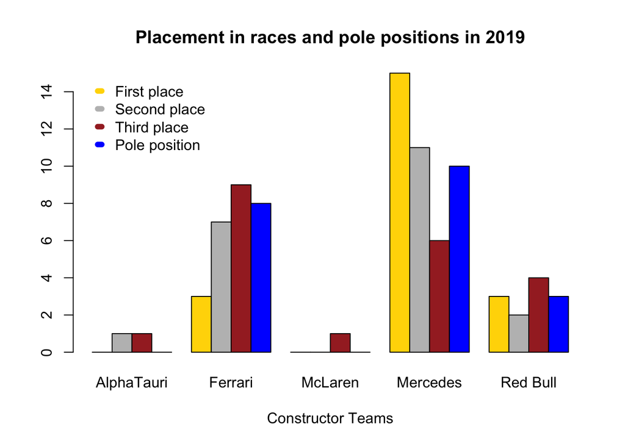

```r
#2019

table(DB2019$Team[DB2019$positionText==1])
table(DB2019$Team[DB2019$positionText==2])
table(DB2019$Team[DB2019$positionText==3])

table(DB2019$Team[DB2019$quali_position==1])

f19=c(0,3,0,15,3)
s19=c(1,7,0,11,2)
t19=c(1,9,1,6,4)
p19=c(0,8,0,10,3)


barplot(rbind(f19,s19,t19,p19),width=5 ,beside = T, names.arg = c("AlphaTauri","Ferrari","McLaren","Mercedes","Red Bull"), col = c("Gold","Grey","Brown","Blue"), main="Placement in races and pole positions in 2019",
        xlab="Constructor Teams")
leg.txta =c("First place","Second place","Third place","Pole position")
legend(3,15,leg.txta,lty=1, bty="n", col =c("Gold","Grey","Brown","Blue"), lwd = 6 ,seg.len = 0.3)
```

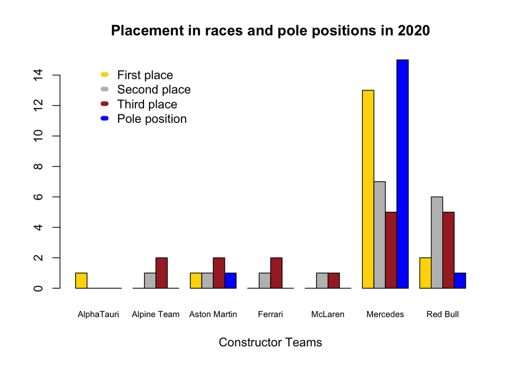

```r
#2020

table(DB2020$Team[DB2020$positionText==1])
table(DB2020$Team[DB2020$positionText==2])
table(DB2020$Team[DB2020$positionText==3])

table(DB2020$Team[DB2020$quali_position==1])

f20=c(1,0,1,0,0,13,2)
s20=c(0,1,1,1,1,7,6)
t20=c(0,2,2,2,1,5,5)
p20=c(0,0,1,0,0,15,1)


barplot(rbind(f20,s20,t20,p20),width=7 ,beside = T, names.arg = c("AlphaTauri","Alpine Team","Aston Martin","Ferrari","McLaren","Mercedes","Red Bull"), col = c("Gold","Grey","Brown","Blue"), main="Placement in races and pole positions in 2020",
        xlab="Constructor Teams",cex.names = 0.7)
leg.txta =c("First place","Second place","Third place","Pole position")
legend(17,15,leg.txta,lty=1, bty="n", col =c("Gold","Grey","Brown","Blue"), lwd = 6 ,seg.len = 0.3)
```

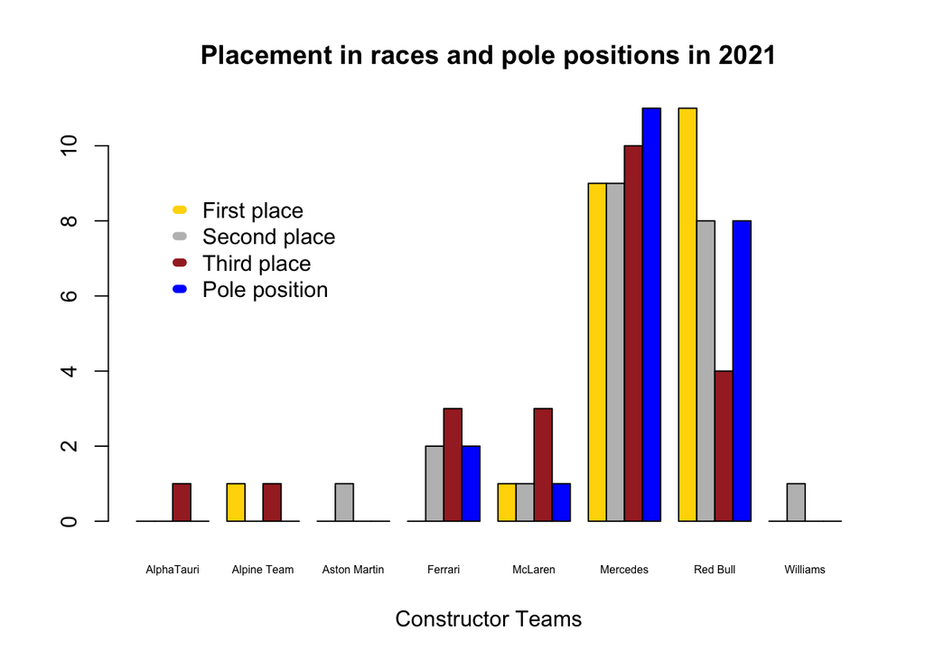

```r
#2021

table(DB2021$Team[DB2021$positionText==1])
table(DB2021$Team[DB2021$positionText==2])
table(DB2021$Team[DB2021$positionText==3])

table(DB2021$Team[DB2021$quali_position==1])

f21=c(0,1,0,0,1,9,11,0)
s21=c(0,0,1,2,1,9,8,1)
t21=c(1,1,0,3,3,10,4,0)
p21=c(0,0,0,2,1,11,8,0)

barplot(rbind(f21,s21,t21,p21),width=8 ,beside = T, names.arg = c("AlphaTauri","Alpine Team","Aston Martin","Ferrari","McLaren","Mercedes","Red Bull","Williams"), col = c("Gold","Grey","Brown","Blue"), main="Placement in races and pole positions in 2021",
        xlab="Constructor Teams",cex.names = 0.5)
leg.txta =c("First place","Second place","Third place","Pole position")
legend(17,9,leg.txta,lty=1, bty="n", col =c("Gold","Grey","Brown","Blue"), lwd = 6 ,seg.len = 0.3)
```

### Splitting the dataset

Now we have our complete dataset. And we will split it in Train and Test set in order to perform our prediction. We will consider in the train set all the races between 2014 and 2020, while our test set will be the year 2021.

```r
#Creating a dataset just with the variables we are interested in
dati1<-data.frame(dati$raceId,dati$DNF,dati$positionText,dati$year,dati$Driver,dati$quali_position,dati$fastestLapTime,dati$fastestLapSpeed , dati$Team,dati$driver_nationality,dati$circuitRef,dati$lat,dati$lng,dati$alt)

dati1$tasso_win<- dati$tasso_win
dati1$tasso_DNF<-dati$tasso_DNF
dati1$dati.fastestLapTime<-as.numeric(dati1$dati.fastestLapTime)
dati1$tasso_DNF<-as.numeric(dati1$tasso_DNF)
dati1$tasso_win<-as.numeric(dati1$tasso_win)

##Considering only the active drivers
dati1<-subset(dati1,dati.Driver=="Alonso" | dati.Driver=="Bottas" | dati.Driver=="Gasly" | dati.Driver=="Giovinazzi" | dati.Driver=="Hamilton" | dati.Driver=="Kubica" | dati.Driver=="Latifi" | dati.Driver=="Leclerc" | dati.Driver=="Norris" | dati.Driver=="Ocon" | dati.Driver=="Pérez" | dati.Driver=="Räikkönen" | dati.Driver=="Ricciardo" | dati.Driver=="Russell" | dati.Driver=="Sainz" | dati.Driver=="Stroll" | dati.Driver=="Verstappen" | dati.Driver=="Vettel")

##Considering just the active circuits
dati1<- subset(dati1, dati.circuitRef=="americas" | dati.circuitRef=="bahrain" | dati.circuitRef=="baku" | dati.circuitRef=="catalunya" | dati.circuitRef=="hungaroring" | dati.circuitRef=="imola" | dati.circuitRef=="interlagos" | dati.circuitRef=="istanbul" | dati.circuitRef=="monaco" | dati.circuitRef=="monza" | dati.circuitRef=="portimao" | dati.circuitRef=="red_bull_ring" | dati.circuitRef=="ricard" | dati.circuitRef=="rodriguez" | dati.circuitRef=="silverstone" | dati.circuitRef=="sochi" | dati.circuitRef=="spa" | dati.circuitRef=="yas_marina")

##Considering just the active circuits
dati1<-subset(dati1, dati.Team!="Marussia")
```

```r
#Creation of the variable TASSO_DNF which is the percentage of DNF of each team
#in each race.

cumulata_gare_scuderia_2014_2021<- data.frame(table(dati1$dati.Team))
cumulata_gare_scuderia_2014_2021$Freq<-0

cumulata_DNF_scuderia_2014_2021<- data.frame(table(dati1$dati.Team))
cumulata_DNF_scuderia_2014_2021$Freq<-0

race_id<-data.frame(table(dati1$dati.raceId))

tasso_DNF_scuderia<-list()
scuderia<-list()
race<-list()
for (i in race_id$Var1) {
  for (j in cumulata_DNF_scuderia_2014_2021$Var1) {
    perc<- (cumulata_DNF_scuderia_2014_2021$Freq[cumulata_DNF_scuderia_2014_2021$Var1==j]/cumulata_gare_scuderia_2014_2021$Freq[cumulata_gare_scuderia_2014_2021$Var1==j])*100
    tasso_DNF_scuderia<-append(tasso_DNF_scuderia,perc)
    scuderia<-append(scuderia,j)
    race<-append(race,i)
    cumulata_gare_scuderia_2014_2021$Freq[cumulata_gare_scuderia_2014_2021$Var1==j]<-cumulata_gare_scuderia_2014_2021$Freq[cumulata_gare_scuderia_2014_2021$Var1==j]+2
    cumulata_DNF_scuderia_2014_2021$Freq[cumulata_DNF_scuderia_2014_2021$Var1==j]<-cumulata_DNF_scuderia_2014_2021$Freq[cumulata_DNF_scuderia_2014_2021$Var1==j]+sum(dati1$dati.DNF[dati1$dati.Team==j & dati1$dati.raceId==i])
  }

}

tasso_DNF_scuderia<-as.numeric(tasso_DNF_scuderia)
scuderia<-as.character(scuderia)
race<-as.numeric(race)
tasso_DNF_scuderia.data<-data.frame(race,scuderia,tasso_DNF_scuderia)
tasso_DNF_scuderia.data$tasso_DNF_scuderia[tasso_DNF_scuderia.data$tasso_DNF_scuderia=="NaN"]<-0

tasso_DNF_scuderia_def<- list()
for (i in 1:nrow(dati1)) {
  tasso_DNF_scuderia_def<-append(tasso_DNF_scuderia_def,tasso_DNF_scuderia.data$tasso_DNF_scuderia[tasso_DNF_scuderia.data$race==dati1$dati.raceId[i] & tasso_DNF_scuderia.data$scuderia==dati1$dati.Team[i]])

}
tasso_DNF_scuderia_def<-as.numeric(tasso_DNF_scuderia_def)
dati1$tasso_DNF_scuderia<-tasso_DNF_scuderia_def
```

```r
#SPLITTING IN TRAIN E TEST
## Training set with all the observation before 2021
train<-subset(dati1, dati.year<2021)

## For the test just the 2021 races
test<- subset(dati1, dati.year==2021)

## Excluding the drivers and circuits that...
test1<-subset(test, dati.Driver!= "Mazepin" & dati.Driver!= "Schumacher" & dati.Driver!= "Tsunoda" & dati.circuitRef!= "jeddah" & dati.circuitRef!= "losail" & dati.circuitRef!= "zandvoort" )
#test1$dati.Driver = as.factor(test1$dati.Driver)
#test1$dati.Team = as.factor(test1$dati.Team)

## Test Set
test2<-test1[,-1]
```

### Setting the target variable to predict

As cited before, the aim of the project is to predict the podiums, the 4-10 and 11-20 positions, so we proceed by encoding the target variable in such a way.

```r
#Encoding of the target variable in train set
train$dati.positionText<-as.numeric(train$dati.positionText)
train$dati.positionText<- ifelse(train$dati.positionText<4,1,ifelse(train$dati.positionText<11,2,3))
train$dati.positionText[is.na(train$dati.positionText)==TRUE]<-3

#Encoding of the target variable in test set
test1$dati.positionText<-as.numeric(test1$dati.positionText)
test1$dati.positionText<- ifelse(test1$dati.positionText<4,1,ifelse(test1$dati.positionText<11,2,3))
test1$dati.positionText[is.na(test1$dati.positionText)==TRUE]<-3
```

In the next step we will store the target variable and the regressors in order to clarify the notation. So, the target variable is the positionText variable; while the regressors are qualify position, the driver, the seconds it took the driver to complete the fastest lap, the speed of the fastest lap, the team, the circuit, the dnf ratio and the driver wins ratio.

```r
y_train = train$dati.positionText
x_train = train[,c(3,5,6,7,8,9,11,15,16,17)]


y_test = test1$dati.positionText
x_test = test2[,c(2,4,5,6,7,8,10,14,15,16)]
```

Let’s check if the independent variables chosen are correlated.

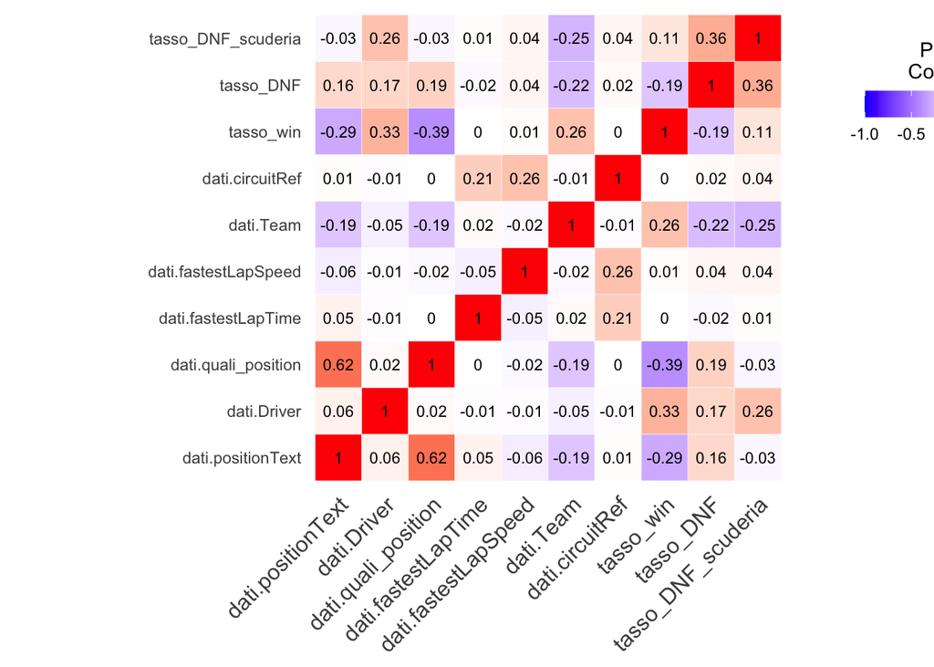

```r
x_train.1<-x_train

x_train.1$dati.Driver<-as.factor(x_train.1$dati.Driver)
x_train.1$dati.Driver<-as.numeric(x_train.1$dati.Driver)

x_train.1$dati.Team<-as.factor(x_train.1$dati.Team)
x_train.1$dati.Team<-as.numeric(x_train.1$dati.Team)

x_train.1$dati.circuitRef<-as.factor(x_train.1$dati.circuitRef)
x_train.1$dati.circuitRef<-as.numeric(x_train.1$dati.circuitRef)

x_train.1$dati.fastestLapTime[is.na(x_train.1$dati.fastestLapTime)==TRUE]<- mean(x_train.1$dati.fastestLapTime[is.na(x_train.1$dati.fastestLapTime)==FALSE])
x_train.1$dati.fastestLapSpeed[is.na(x_train.1$dati.fastestLapSpeed)==TRUE]<- mean(x_train.1$dati.fastestLapSpeed[is.na(x_train.1$dati.fastestLapSpeed)==FALSE])

d<-round(cor(x_train.1),2)
library(ggplot2)
library(reshape2)
melted_cormat <- melt(d)

# Create a ggheatmap
ggheatmap <- ggplot(melted_cormat, aes(Var2, Var1, fill = value))+
  geom_tile(color = "white")+
  scale_fill_gradient2(low = "blue", high = "red", mid = "white",
                       midpoint = 0, limit = c(-1,1), space = "Lab",
                       name="Pearson\nCorrelation") +
  theme_minimal()+ # minimal theme
  theme(axis.text.x = element_text(angle = 45, vjust = 1,
                                   size = 12, hjust = 1))+
  coord_fixed()

ggheatmap +
  geom_text(aes(Var2, Var1, label = value), color = "black", size = 3) +
  theme(
    axis.title.x = element_blank(),
    axis.title.y = element_blank(),
    panel.grid.major = element_blank(),
    panel.border = element_blank(),
    panel.background = element_blank(),
    axis.ticks = element_blank(),
    legend.justification = c(1, 0),
    legend.position = c(1.58, 0.7),
    legend.direction = "horizontal")+
  guides(fill = guide_colorbar(barwidth = 7, barheight = 1,
                               title.position = "top", title.hjust = 0.5))
```

### Models

```r
require(foreign)
require(ggplot2)
require(MASS)
require(Hmisc)
require(reshape2)
library(Metrics)
```

The Ordered Logistic Regression is the first model we applied since it is the one that best meets our needs. The assumptions behind this model are: • The dependent target variable has to be ordered • One or more of the independent variables are either continuous, categorical or ordinal • No multi-collinearity. All the assumptions are verified since our target variable is ordered: it assumes values 1,2 or 3 based on the positions classes gained during the race

```r
## ORDERED LOGISTIC REGRESSION
m <- polr(as.factor(dati.positionText) ~. , data = x_train, Hess=TRUE)
c<-data.frame(x_test)
pred<-predict(m,c)
predd<- data.frame(y_test,pred)
table(y_test,pred)
```

```
##       pred
## y_test  1  2  3
##      1 39 14  1
##      2 14 70 35
##      3  6 27 89
```

```r
library(Metrics)
rmse_olr<-rmse(as.numeric(predd$y_test[is.na(predd$pred)==FALSE]),as.numeric(predd$pred[is.na(predd$pred)==FALSE]))
rmse_olr
```

```
## [1] 0.6324555
```

```r
accuracy(as.numeric(predd$y_test[is.na(predd$pred)==FALSE]),as.numeric(predd$pred[is.na(predd$pred)==FALSE]))
```

```
## [1] 0.6711864
```

```r
results <- list()
results <- append(results, rmse_olr)
```

A Random Forest Classifier is an algorithm that with an ensemble technique builds different decision trees on bootstrapped data observation and a subset of features. Each model is trained independently and generates a result: then the final output is based on majority voting after combining the results of all models.

```r
#RANDOM FOREST
library(randomForest)
library(caret)
rf <- randomForest(as.factor(dati.positionText) ~. , data = x_train, proximity = TRUE, na.action=na.exclude, ntree=10000, cross=10, mtry = 4)
print(rf)
```

```
##
## Call:
##  randomForest(formula = as.factor(dati.positionText) ~ ., data = x_train,      proximity = TRUE, ntree = 10000, cross = 10, mtry = 4, na.action = na.exclude)
##                Type of random forest: classification
##                      Number of trees: 10000
## No. of variables tried at each split: 4
##
##         OOB estimate of  error rate: 35.97%
## Confusion matrix:
##     1   2   3 class.error
## 1 171  76   9   0.3320312
## 2  71 302  88   0.3449024
## 3  18 134 232   0.3958333
```

```r
##prediction on test set
p3 <- predict(rf, x_test)
predd.3<- data.frame(y_test,p3)
rmse_rf = rmse(as.numeric(predd.3$y_test[is.na(predd.3$p3)==FALSE]),as.numeric(predd.3$p3[is.na(predd.3$p3)==FALSE]))

rmse_rf
```

```
## [1] 0.6483355
```

```r
table(truth = y_test,pred= p3)
```

```
##      pred
## truth  1  2  3
##     1 36 16  2
##     2  9 89 21
##     3  7 42 73
```

```r
accuracy(as.numeric(predd.3$y_test[is.na(predd.3$p3)==FALSE]), as.numeric(predd.3$p3[is.na(predd.3$p3)==FALSE]))
```

```
## [1] 0.6711864
```

```r
x_test.1<-x_test

x_test.1$dati.Driver<-as.factor(x_test.1$dati.Driver)
x_test.1$dati.Driver<-as.numeric(x_test.1$dati.Driver)

x_test.1$dati.Team<-as.factor(x_test.1$dati.Team)
x_test.1$dati.Team<-as.numeric(x_test.1$dati.Team)

x_test.1$dati.circuitRef<-as.factor(x_test.1$dati.circuitRef)
x_test.1$dati.circuitRef<-as.numeric(x_test.1$dati.circuitRef)

x_test.1$dati.fastestLapTime[is.na(x_test.1$dati.fastestLapTime)==TRUE]<- mean(x_test.1$dati.fastestLapTime[is.na(x_test.1$dati.fastestLapTime)==FALSE])
x_test.1$dati.fastestLapSpeed[is.na(x_test.1$dati.fastestLapSpeed)==TRUE]<- mean(x_test.1$dati.fastestLapSpeed[is.na(x_test.1$dati.fastestLapSpeed)==FALSE])
```

The Naive Bayes Classifier is an algorithm based on Bayes’ Theorem with strong hypothesis of in- dependence between the independent variables. It is used for classification tasks, both binary and multiclass. In our analysis, it is quite useful since the independent variables don’t have strong relation- ships.

```r
## NAIVE BAYES CLASSIFIER
model <- naive_bayes(as.factor(dati.positionText)~ ., data = x_train.1, usekernel = T)


## prediction on test set
p_nb_test <- predict(model, x_test.1)
tab3 <- table(p_nb_test, (y_test))

##accuracy_nb = sum(diag(tab3)) / sum(tab3)
##accuracy_nb
accuracy(as.factor(y_test), p_nb_test)
```

```
## [1] 0.6594427
```

Support vector machines are supervised learning models with associated learning algorithms that ana- lyze data used for classification and regression analysis. The algorithm creates a line or a hyperplane which separates the data into classes.The best hyperplane is the hyperplane whose distance to the nearest element of each tag is the largest.

```r
## SVM
library(e1071)
svmfit = svm(as.factor(dati.positionText)~ ., data = x_train.1, kernel = "linear", gamma=10^(-4), cost = 100, scale = TRUE, na.action = na.omit)
#prediction
pred_svm <- predict(svmfit,x_test.1)
accuracy(pred_svm,y_test)
```

```
## [1] 0.6501548
```

```r
table(pred_svm,y_test)
```

```
##         y_test
## pred_svm  1  2  3
##        1 41 18 14
##        2 13 76 33
##        3  3 32 93
```

### Comparison of the models

```r
## Ordered Logistic Regression
print("Ordered Logistic Regression")
```

```
## [1] "Ordered Logistic Regression"
```

```r
c_ol <- confusionMatrix(pred,as.factor(y_test))
round(c_ol$byClass[,c(1,2,5,6,11)],3)
```

```
##          Sensitivity Specificity Precision Recall Balanced Accuracy
## Class: 1       0.722       0.917     0.661  0.722             0.820
## Class: 2       0.588       0.767     0.631  0.588             0.678
## Class: 3       0.730       0.792     0.712  0.730             0.761
```

```r
## Random Forest model
print("Random Forest model")
```

```
## [1] "Random Forest model"
```

```r
c_rf <- confusionMatrix(p3,as.factor(y_test))
round(c_rf$byClass[,c(1,2,5,6,11)],3)
```

```
##          Sensitivity Specificity Precision Recall Balanced Accuracy
## Class: 1       0.667       0.934     0.692  0.667             0.800
## Class: 2       0.748       0.670     0.605  0.748             0.709
## Class: 3       0.598       0.867     0.760  0.598             0.733
```

```r
## Naive Bayes Classifier
print("Naive Bayes Classifier")
```

```
## [1] "Naive Bayes Classifier"
```

```r
c_nb <- confusionMatrix(p_nb_test,as.factor(y_test))
round(c_nb$byClass[,c(1,2,5,6,11)],3)
```

```
##          Sensitivity Specificity Precision Recall Balanced Accuracy
## Class: 1       0.684       0.914     0.629  0.684             0.799
## Class: 2       0.698       0.716     0.611  0.698             0.707
## Class: 3       0.614       0.831     0.735  0.614             0.722
```

```r
##SVM
print("Support Vector classifier")
```

```
## [1] "Support Vector classifier"
```

```r
c_svm <- confusionMatrix(pred_svm,as.factor(y_test))
round(c_svm$byClass[,c(1,2,5,6,11)],3)
```

```
##          Sensitivity Specificity Precision Recall Balanced Accuracy
## Class: 1       0.719       0.880     0.562  0.719             0.799
## Class: 2       0.603       0.766     0.623  0.603             0.685
## Class: 3       0.664       0.809     0.727  0.664             0.737
```

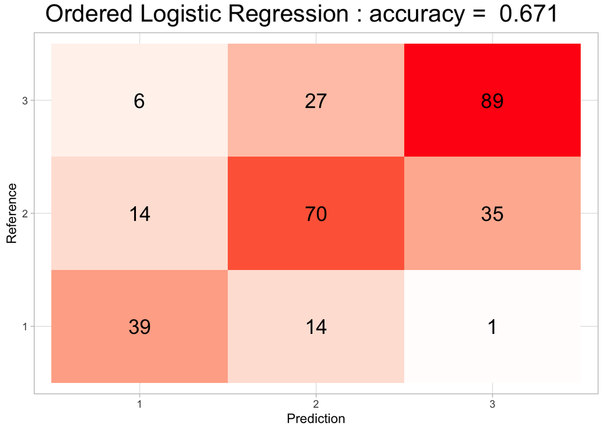

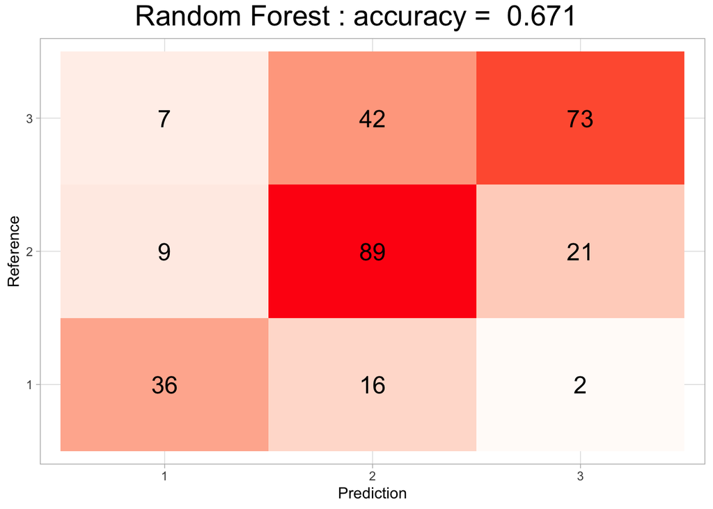

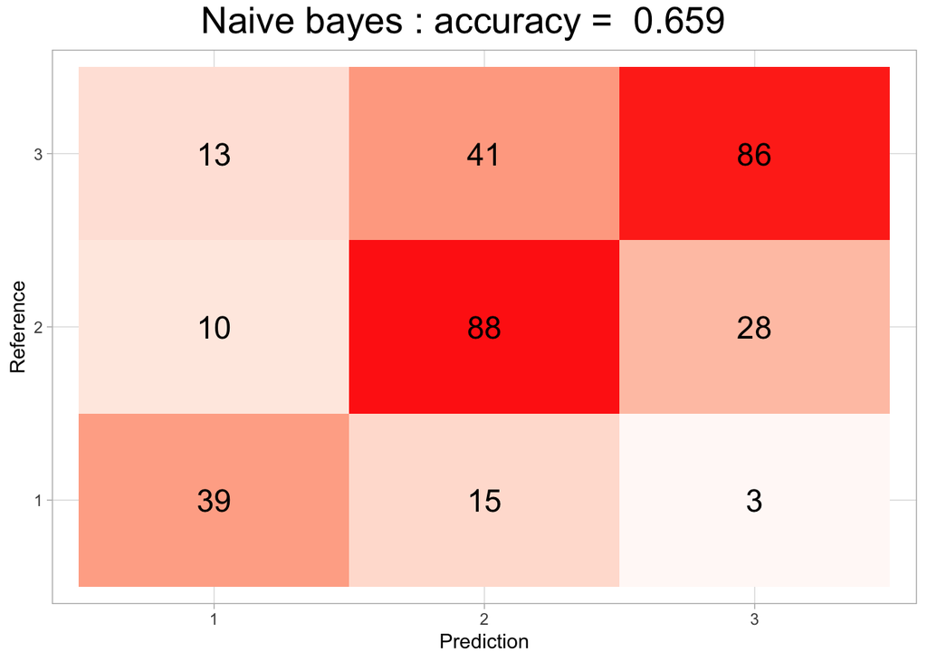

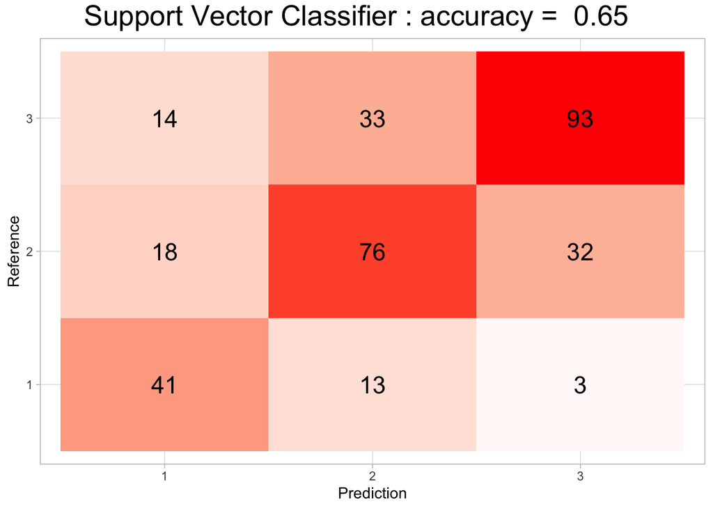

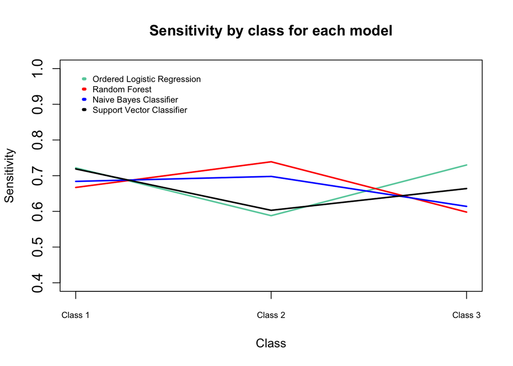

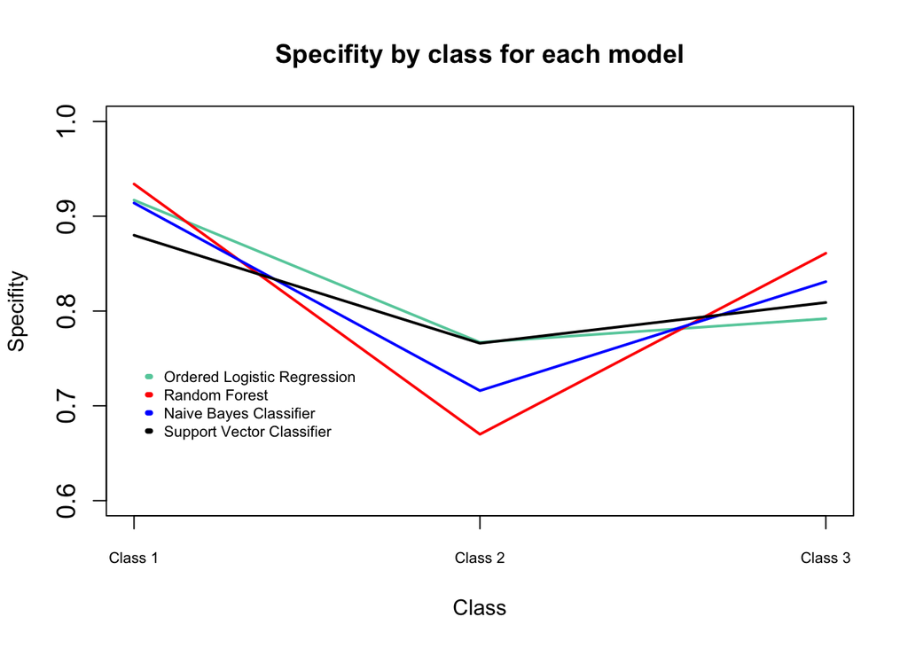

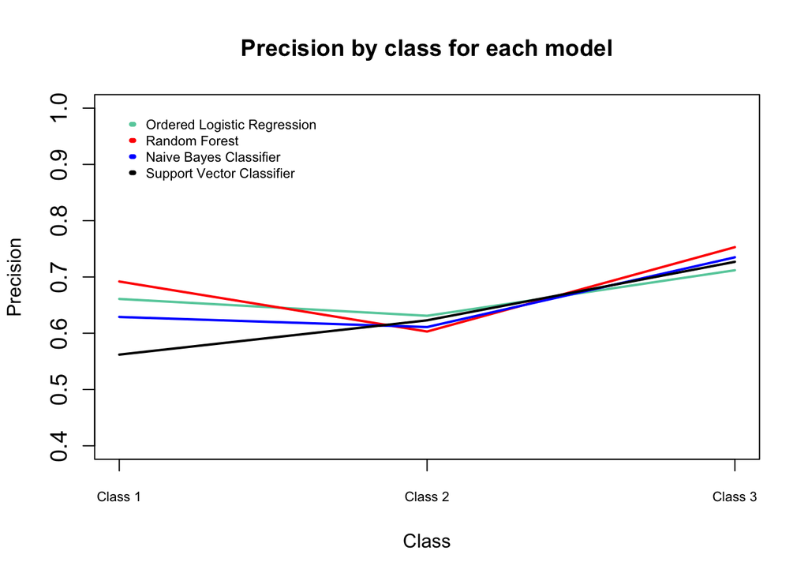

These plots are very interesting since they show the sensitivity, the specifity and the precision of the classification for each class and for each model. We can observe that the models slightly differ when predicting the different classes. For example, Random Forest is the model which best predict the class ’2’ with a very high sensitivity with respect to the other models. Analyzing the specificity of the second class, the OLR has the highest value for the class ’2’ because it is the one that predicts the worst class ’2’ but at the same time it makes less mistakes than the other models.

### Conclusion

These plots are very interesting since they show the sensitivity, the specifity and the precision of the classification for each class and for each model. We can observe that the models slightly differ when predicting the different classes. For example, Random Forest is the model which best predict the class ’2’ with a very high sensitivity with respect to the other models. Analyzing the specificity of the second class, the OLR has the highest value for the class ’2’ because it is the one that predicts the worst class ’2’ but at the same time it makes less mistakes than the other models.